# Assignement- 2

Ahaan Tagare

2025-01-13

Student - 33865799

##### STATISTICS AND STATISTICAL DATA MINING

### **Predictive Modelling for Loan Approval: A Comparative Analysis of Machine Learning Techniques**

Dataset - https://www.kaggle.com/datasets/zaurbegiev/my-dataset?select=credit_train.csv

The code’s libraries perform a number of vital operations for data analysis and machine learning projects While dplyr and tidyr are used for data manipulation and tidying, R. gbm is used for gradient boosting models. Caret provides a uniform interface for training and assessing machine learning models, while ggplot2 makes sophisticated visualizations possible. ROC curves and AUC are used by pROC to assess classifier performance, while randomforest creates random forest models. rpart and rpart.plot with an emphasis on decision tree visualizations and models. PDP uses partial dependence plots to help visualize model behavior, and Rumble offers a graphical user interface for data science. NeuralNetTools helps with neural network analysis, nnet is used for neural network training, and coefplot visualizes regression model coefficients. Data preparation and imbalanced datasets are handled by DMwR, while DiagrammeR generates graphical diagrams for network or workflow visualization. Finally, data can be reshaped between wide and long formats using reshape2. Together, these packages offer a complete toolkit for modeling, data wrangling, visualization, and model validation, have suppressed the warnings because of the setting control in the PC in this code which would make no impact on the model.

```r
suppressPackageStartupMessages({
  suppressWarnings({
    library(gbm)
    library(dplyr)
    library(tidyr)
    library(ggplot2)
    library(caret)
    library(randomForest)
    library(pROC)
    library(rpart)
    library(rpart.plot)
    library(rattle)
    library(pdp)
    library(coefplot)
    library(NeuralNetTools)
    library(nnet)
    library(DMwR)
    library(DiagrammeR)
    library(reshape2)
    library(scales)
  })
})
```

```r
# Data preprocessing
data <- read.csv("Credit_data.csv")
str(data)
```

```
## 'data.frame':    100514 obs. of  19 variables:
##  $ Loan.ID                     : chr  "14dd8831-6af5-400b-83ec-68e61888a048" "4771cc26-131a-45db-b5aa-537ea4ba5342" "4eed4e6a-aa2f-4c91-8651-ce984ee8fb26" "77598f7b-32e7-4e3b-a6e5-06ba0d98fe8a" ...
##  $ Customer.ID                 : chr  "981165ec-3274-42f5-a3b4-d104041a9ca9" "2de017a3-2e01-49cb-a581-08169e83be29" "5efb2b2b-bf11-4dfd-a572-3761a2694725" "e777faab-98ae-45af-9a86-7ce5b33b1011" ...
##  $ Loan.Status                 : chr  "Fully Paid" "Fully Paid" "Fully Paid" "Fully Paid" ...
##  $ Current.Loan.Amount         : int  445412 262328 99999999 347666 176220 206602 217646 648714 548746 215952 ...
##  $ Term                        : chr  "Short Term" "Short Term" "Short Term" "Long Term" ...
##  $ Credit.Score                : int  709 NA 741 721 NA 7290 730 NA 678 739 ...
##  $ Annual.Income               : int  1167493 NA 2231892 806949 NA 896857 1184194 NA 2559110 1454735 ...
##  $ Years.in.current.job        : chr  "8 years" "10+ years" "8 years" "3 years" ...
##  $ Home.Ownership              : chr  "Home Mortgage" "Home Mortgage" "Own Home" "Own Home" ...
##  $ Purpose                     : chr  "Home Improvements" "Debt Consolidation" "Debt Consolidation" "Debt Consolidation" ...
##  $ Monthly.Debt                : num  5215 33296 29201 8742 20640 ...
##  $ Years.of.Credit.History     : num  17.2 21.1 14.9 12 6.1 17.3 19.6 8.2 22.6 13.9 ...
##  $ Months.since.last.delinquent: int  NA 8 29 NA NA NA 10 8 33 NA ...
##  $ Number.of.Open.Accounts     : int  6 35 18 9 15 6 13 15 4 20 ...
##  $ Number.of.Credit.Problems   : int  1 0 1 0 0 0 1 0 0 0 ...
##  $ Current.Credit.Balance      : int  228190 229976 297996 256329 253460 215308 122170 193306 437171 669560 ...
##  $ Maximum.Open.Credit         : int  416746 850784 750090 386958 427174 272448 272052 864204 555038 1021460 ...
##  $ Bankruptcies                : int  1 0 0 0 0 0 1 0 0 0 ...
##  $ Tax.Liens                   : int  0 0 0 0 0 0 0 0 0 0 ...
```

```r
# Create the flowchart
flowchart <- grViz("
digraph workflow {
  graph [layout = dot, rankdir = TB]

  # Nodes
  node [shape = box, style = filled, color = lightblue]
  A [label = 'Load and Inspect Data']
  B [label = 'Data Cleaning and Preprocessing']
  C1 [label = 'Handle Missing Values']
  C2 [label = 'Variable Conversion']
  D [label = 'Feature Engineering']
  D1 [label = 'Calculate DTI']
  D2 [label = 'Credit Utilization']
  E [label = 'Train-Test Split']
  F [label = 'Model Training and Evaluation']
  F1 [label = 'Decision Tree']
  F2 [label = 'Random Forest']
  F3 [label = 'Logistic Regression']
  F4 [label = 'Gradient Boosting']
  F5 [label = 'Artificial Neural Network']
  G [label = 'Model Evaluation']
  G1 [label = 'Accuracy, Precision, Recall, F1 Score']
  H [label = 'Model Comparison']
  I [label = 'ROC Analysis']

  # Edges
  A -> B
  B -> C1
  B -> C2
  C1 -> D
  C2 -> D
  D -> D1
  D -> D2
  D1 -> E
  D2 -> E
  E -> F
  F -> F1
  F -> F2
  F -> F3
  F -> F4
  F -> F5
  F1 -> G
  F2 -> G
  F3 -> G
  F4 -> G
  F5 -> G
  G -> G1
  G1 -> H
  H -> I
}
")

# Render the flowchart
flowchart
```

[interactive chart not shown]

This code prepares data for a pie chart that displays column counts by loading a dataset and counting non-missing values for each column. After determining the cumulative midpoints and proportions for label placement, it gives each column a distinct color. The text labels are positioned inside the chart slices after a pie chart with personalized labels, colors, and a legend is created using ggplot2. As a result, column names and counts are shown in an eye-catching pie chart.

```r
# Data preprocessing
data <- read.csv("Credit_data.csv")
str(data)
```

```
## 'data.frame':    100514 obs. of  19 variables:
##  $ Loan.ID                     : chr  "14dd8831-6af5-400b-83ec-68e61888a048" "4771cc26-131a-45db-b5aa-537ea4ba5342" "4eed4e6a-aa2f-4c91-8651-ce984ee8fb26" "77598f7b-32e7-4e3b-a6e5-06ba0d98fe8a" ...
##  $ Customer.ID                 : chr  "981165ec-3274-42f5-a3b4-d104041a9ca9" "2de017a3-2e01-49cb-a581-08169e83be29" "5efb2b2b-bf11-4dfd-a572-3761a2694725" "e777faab-98ae-45af-9a86-7ce5b33b1011" ...
##  $ Loan.Status                 : chr  "Fully Paid" "Fully Paid" "Fully Paid" "Fully Paid" ...
##  $ Current.Loan.Amount         : int  445412 262328 99999999 347666 176220 206602 217646 648714 548746 215952 ...
##  $ Term                        : chr  "Short Term" "Short Term" "Short Term" "Long Term" ...
##  $ Credit.Score                : int  709 NA 741 721 NA 7290 730 NA 678 739 ...
##  $ Annual.Income               : int  1167493 NA 2231892 806949 NA 896857 1184194 NA 2559110 1454735 ...
##  $ Years.in.current.job        : chr  "8 years" "10+ years" "8 years" "3 years" ...
##  $ Home.Ownership              : chr  "Home Mortgage" "Home Mortgage" "Own Home" "Own Home" ...
##  $ Purpose                     : chr  "Home Improvements" "Debt Consolidation" "Debt Consolidation" "Debt Consolidation" ...
##  $ Monthly.Debt                : num  5215 33296 29201 8742 20640 ...
##  $ Years.of.Credit.History     : num  17.2 21.1 14.9 12 6.1 17.3 19.6 8.2 22.6 13.9 ...
##  $ Months.since.last.delinquent: int  NA 8 29 NA NA NA 10 8 33 NA ...
##  $ Number.of.Open.Accounts     : int  6 35 18 9 15 6 13 15 4 20 ...
##  $ Number.of.Credit.Problems   : int  1 0 1 0 0 0 1 0 0 0 ...
##  $ Current.Credit.Balance      : int  228190 229976 297996 256329 253460 215308 122170 193306 437171 669560 ...
##  $ Maximum.Open.Credit         : int  416746 850784 750090 386958 427174 272448 272052 864204 555038 1021460 ...
##  $ Bankruptcies                : int  1 0 0 0 0 0 1 0 0 0 ...
##  $ Tax.Liens                   : int  0 0 0 0 0 0 0 0 0 0 ...
```

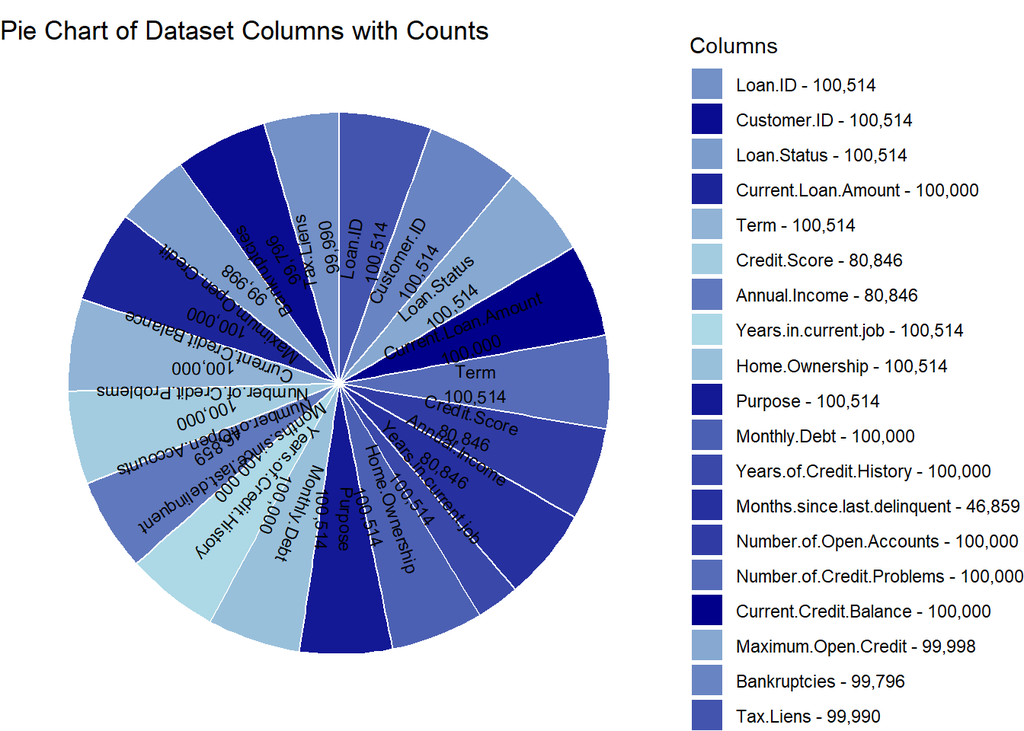

```r
column_names <- colnames(data)
counts <- colSums(!is.na(data))

# Prepare the data forpie chart
pie_data <- data.frame(Column = column_names, Count = counts)


pie_data$Proportion <- pie_data$Count / sum(pie_data$Count)
pie_data$Cumulative <- cumsum(pie_data$Proportion) - pie_data$Proportion / 2


pie_data$Legend_Label <- paste0(pie_data$Column, " - ", scales::comma(pie_data$Count))


color_palette <- colorRampPalette(c("lightblue", "darkblue"))(nrow(pie_data))



ggplot(pie_data, aes(x = "", y = Count, fill = Legend_Label)) +
  geom_bar(stat = "identity", width = 1, color = "white") +
  coord_polar("y", start = 0) +
  theme_void() +
  labs(
    title = "Pie Chart of Dataset Columns with Counts",
    fill = "Columns"
  ) +
  theme(legend.position = "right") +
  scale_fill_manual(
    values = setNames(color_palette, pie_data$Legend_Label),  # Match colors explicitly to labels
    labels = pie_data$Legend_Label
  ) +
  geom_text(
    aes(
      y = Cumulative * sum(Count),
      label = paste(Column, scales::comma(Count), sep = "\n")  # Add names and counts
    ),
    size = 3,
    angle = 90 - (pie_data$Cumulative * 360),
    hjust = 0.5, color = "black"
  )
```

```r
data[is.na(data)] <- 0
data$Term <- ifelse(data$Term == "Short Term", 0, 1)
data$Months.since.last.delinquent[is.na
(data$Months.since.last.delinquent)] <- mean(data$Months.since.last.delinquent, na.rm = TRUE)
```

This code cleans the `Years.in.current.job` column by removing the word years and replacing 10+ with 10. It converts the column to numeric, suppressing warnings for non-numeric values. Missing or invalid values are replaced with 0. Finally, it prints the dimensions of the cleaned data set using `dim(data)`.

```r
# Clean Years

data$Years.in.current.job <- gsub(" years", "", data$Years.in.current.job)
data$Years.in.current.job[data$Years.in.current.job == "10+"] <- 10
data$Years.in.current.job <- suppressWarnings(as.numeric(data$Years.in.current.job))
data$Years.in.current.job[is.na(data$Years.in.current.job)] <- 0

print(dim(data))
```

```
## [1] 100514     19
```

```r
# Converting the columns to factors
data$Home.Ownership <- as.factor(data$Home.Ownership)
data$Purpose <- as.factor(data$Purpose)


home_ownership_levels <- levels(data$Home.Ownership)
home_ownership_codes <- as.integer(data$Home.Ownership)


purpose_levels <- levels(data$Purpose)
purpose_codes <- as.integer(data$Purpose)


home_ownership_table <- data.frame(Level = home_ownership_levels,
Code = unique(home_ownership_codes))


purpose_table <- data.frame(Level = purpose_levels,
Code = unique(purpose_codes))


print(home_ownership_table)
```

```
##           Level Code
## 1                  3
## 2  HaveMortgage    4
## 3 Home Mortgage    5
## 4      Own Home    2
## 5          Rent    1
```

```r
print(purpose_table)
```

```
##                   Level Code
## 1                          7
## 2         Business Loan    5
## 3             Buy a Car    4
## 4             Buy House   11
## 5    Debt Consolidation    2
## 6  Educational Expenses    3
## 7     Home Improvements    8
## 8        major_purchase   15
## 9         Medical Bills   12
## 10               moving   14
## 11                other    9
## 12                Other   17
## 13     renewable_energy   16
## 14       small_business    6
## 15          Take a Trip   10
## 16             vacation   13
## 17              wedding    1
```

```r
# Feature Engineering
data$DTI <- data$Monthly.Debt / data$Annual.Income
data$DTI[is.na(data$DTI) | is.infinite(data$DTI)] <- 0
data$Credit.Utilization <- data$Current.Credit.Balance /
data$Maximum.Open.Credit
data$Credit.Utilization[is.na(data$Credit.Utilization)] <- 0

print(head(data$DTI))
```

```
## [1] 0.004466614 0.000000000 0.013083308 0.010833274 0.000000000 0.018250111
```

```r
print(head(data$Credit.Utilization))
```

```
## [1] 0.5475517 0.2703107 0.3972803 0.6624207 0.5933414 0.7902719
```

```r
data$LoanApproval <- ifelse(data$Current.Loan.Amount > 500000, 1, 0)
print(dim(data))
```

```
## [1] 100514     22
```

```r
trainIndex <- createDataPartition(data$LoanApproval, p = 0.7, list = FALSE)
train_data <- data[trainIndex, ]
test_data <- data[-trainIndex, ]

dim(train_data)
```

```
## [1] 70360    22
```

```r
dim(test_data)
```

```
## [1] 30154    22
```

```r
train_data[sapply(train_data, is.infinite)] <- 0
test_data[sapply(test_data, is.infinite)] <- 0
```

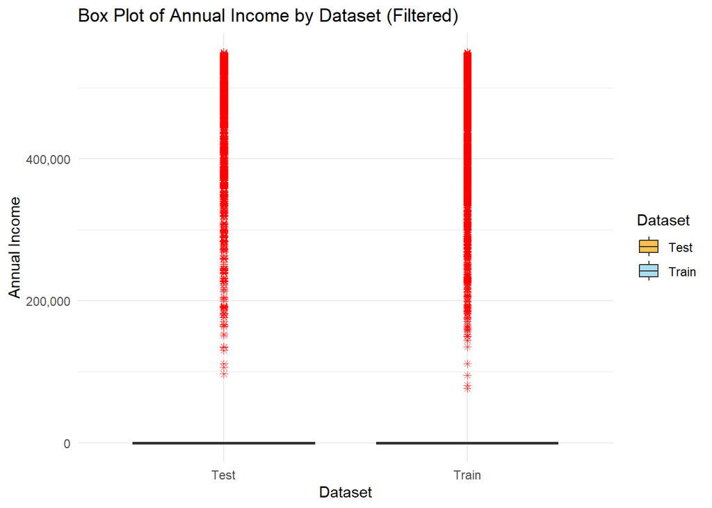

```r
#Box plot
train_data$Dataset <- "Train"
test_data$Dataset <- "Test"

# Combine
combined_data <- rbind(
  train_data[, c("Annual.Income", "Dataset")],
  test_data[, c("Annual.Income", "Dataset")]
)

# Filter
filtered_data <- combined_data[combined_data$Annual.Income < 550000, ]  # Keep values < 500,000

# box plot
ggplot(filtered_data, aes(x = Dataset, y = Annual.Income, fill = Dataset)) +
  geom_boxplot(outlier.color = "red", outlier.shape = 8, alpha = 0.7) +
  theme_minimal() +
  labs(
    title = "Box Plot of Annual Income by Dataset (Filtered)",
    x = "Dataset",
    y = "Annual Income"
  ) +
  scale_fill_manual(values = c("Train" = "skyblue", "Test" = "orange")) +
  theme(axis.text.x = element_text(angle = 0, hjust = 0.5)) +
  scale_y_continuous(labels = scales::comma)
```

```r
train_data_numeric <- train_data[, sapply(train_data, is.numeric)]

# Standardize
train_data_scaled <- scale(train_data_numeric)

pca <- prcomp(train_data_scaled, center = TRUE, scale. = TRUE)

# Summary
summary(pca)
```

```
## Importance of components:
##                           PC1    PC2     PC3     PC4     PC5     PC6     PC7
## Standard deviation     1.6163 1.4131 1.23037 1.11789 1.05004 1.04569 1.00639
## Proportion of Variance 0.1537 0.1175 0.08905 0.07351 0.06486 0.06432 0.05958
## Cumulative Proportion  0.1537 0.2711 0.36018 0.43369 0.49855 0.56287 0.62245
##                            PC8     PC9    PC10    PC11    PC12    PC13   PC14
## Standard deviation     0.98986 0.97775 0.94934 0.91771 0.88862 0.81725 0.7177
## Proportion of Variance 0.05764 0.05623 0.05301 0.04954 0.04645 0.03929 0.0303
## Cumulative Proportion  0.68008 0.73632 0.78933 0.83887 0.88532 0.92461 0.9549
##                           PC15    PC16    PC17
## Standard deviation     0.63867 0.53554 0.26815
## Proportion of Variance 0.02399 0.01687 0.00423
## Cumulative Proportion  0.97890 0.99577 1.00000
```

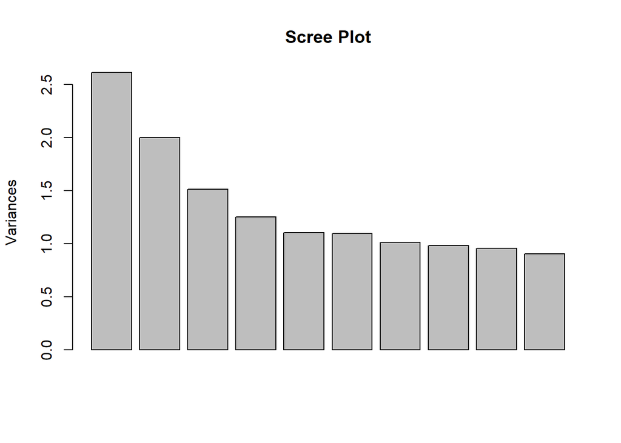

```r
screeplot(pca, main = "Scree Plot")
```

```r
pca_data <- data.frame(pca$x)


pca_train_data <- cbind(pca_data, LoanApproval = train_data$LoanApproval)

head(pca_train_data)
```

|  | PC1 | PC2 | PC3 | PC4 | PC5 | PC6 | PC7 | PC8 | PC9 | PC10 | PC11 | PC12 | PC13 | PC14 | PC15 | PC16 | PC17 | LoanApproval |
| --- | --- | --- | --- | --- | --- | --- | --- | --- | --- | --- | --- | --- | --- | --- | --- | --- | --- | --- |
| 1 | -1.9510969 | -2.0392346 | 0.2063426 | 0.2308344 | 0.9542964 | 0.2659919 | 0.47066752 | -0.9366036 | 1.730050556 | 0.18846506 | -0.2406377 | 0.74250171 | -0.45469652 | 0.1385032 | -0.30319390 | -0.1691193 | -0.116057677 | 0 |
| 5 | -1.0176898 | 1.0619195 | 0.3762030 | 0.5829900 | 0.4895151 | -0.8314951 | -0.07118116 | 1.1797183 | 0.421019245 | -0.03708299 | 0.8434822 | 0.34281615 | -1.31983190 | 0.8671005 | 0.26410344 | 0.3278376 | -0.007985054 | 0 |
| 6 | 0.2329660 | 0.5861326 | 1.4656872 | -3.2820883 | 0.7061929 | 0.9415271 | 1.10984683 | -2.1966172 | -0.007162443 | 1.84906223 | 0.2352460 | -1.27165997 | -1.31552804 | 0.2490265 | 0.57132593 | 0.2907585 | -0.004284539 | 0 |
| 7 | -1.6052254 | -2.2106766 | 0.3154369 | -0.2285383 | -0.4913236 | -0.6106514 | 0.53695493 | 0.1763485 | 1.536998356 | -1.01928996 | -0.9383871 | -0.05111888 | -0.09844658 | 0.5379556 | -0.25342768 | -0.1759179 | -0.123817695 | 0 |
| 8 | -0.6911359 | 0.8344938 | -1.4342995 | 0.5682891 | -0.3847736 | -1.6493635 | -2.24698856 | 0.4689856 | -0.341330340 | -1.08211013 | -0.1574059 | -0.33627798 | -0.97114068 | 0.3130989 | 0.61748969 | -0.8819757 | -0.018361218 | 1 |
| 10 | 1.9382898 | 0.4524906 | 1.4619934 | -1.1279564 | -0.4207809 | -1.4056848 | 0.73482559 | 1.8972670 | 0.780250511 | -0.88577463 | 0.3805687 | -0.15286852 | 0.19410105 | 0.0668143 | -0.08526532 | 0.1648148 | 0.001684343 | 0 |

The code trains a Decision Tree model (`dt_model`) on the `train_data` dataset, using several predictors and the `LoanApproval` target variable with the method `class` for classification. It then visualizes the trained decision tree using `rpart.plot`. The model is used to make predictions (`dt_predictions`) on the `test_data`, ensuring that both the predictions and actual values have the same factor levels. The confusion matrix (`dt_conf_matrix`) is calculated to evaluate the model’s performance, and it is printed for review.

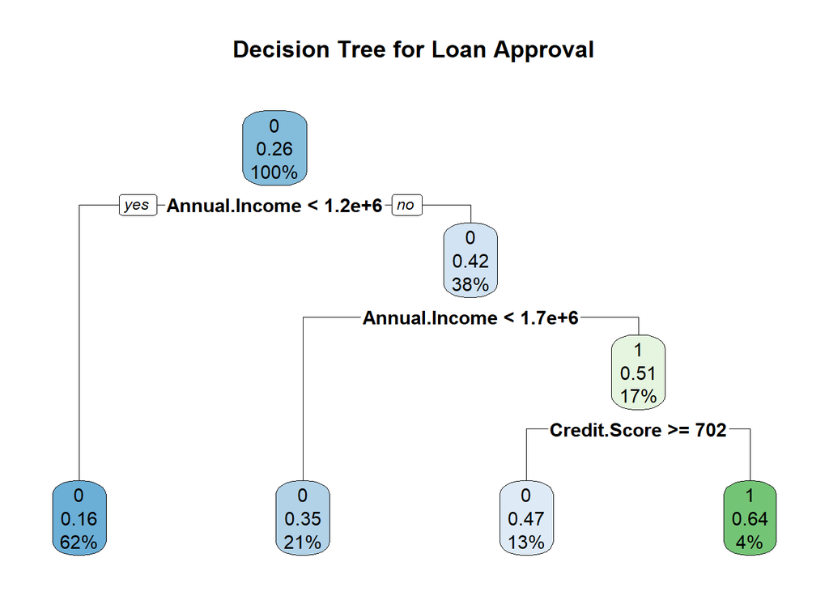

```r
#  Decision Tree Model
dt_model <- rpart(
  LoanApproval ~ Annual.Income + DTI + Credit.Score +
    Years.in.current.job + Credit.Utilization + Home.Ownership + Purpose,
  data = train_data,
  method = "class",
  control = rpart.control(cp = 0.01)
)

# Visualize
rpart.plot(dt_model, main = "Decision Tree for Loan Approval")
```

```r
# Test Data
dt_predictions <- predict(dt_model, test_data, type = "class")


test_data$LoanApproval <- factor(test_data$LoanApproval)
dt_predictions <- factor(dt_predictions, levels = levels(test_data$LoanApproval))

dt_conf_matrix <- confusionMatrix(dt_predictions, test_data$LoanApproval)

print(dt_conf_matrix)
```

```
## Confusion Matrix and Statistics
##
##           Reference
## Prediction     0     1
##          0 21791  7154
##          1   414   795
##
##                Accuracy : 0.749
##                  95% CI : (0.7441, 0.7539)
##     No Information Rate : 0.7364
##     P-Value [Acc > NIR] : 2.89e-07
##
##                   Kappa : 0.1118
##
##  Mcnemar's Test P-Value : < 2.2e-16
##
##             Sensitivity : 0.9814
##             Specificity : 0.1000
##          Pos Pred Value : 0.7528
##          Neg Pred Value : 0.6576
##              Prevalence : 0.7364
##          Detection Rate : 0.7227
##    Detection Prevalence : 0.9599
##       Balanced Accuracy : 0.5407
##
##        'Positive' Class : 0
##
```

```r
# Random Forest Model
train_data$LoanApproval <- factor(train_data$LoanApproval)
test_data$LoanApproval <- factor(test_data$LoanApproval)

rf_model <- randomForest(
  LoanApproval ~ Annual.Income + DTI + Credit.Score + Years.in.current.job + Credit.Utilization + Home.Ownership + Purpose,
  data = train_data,
  ntree = 100
)

rf_predictions <- predict(rf_model, test_data)
rf_conf_matrix <- confusionMatrix(rf_predictions, test_data$LoanApproval)

# Test Data
rf_predictions <- predict(rf_model, test_data)

# Convert
rf_predictions <- factor(rf_predictions, levels = levels(test_data$LoanApproval))

# Confusion Matrix
rf_conf_matrix <- confusionMatrix(rf_predictions, test_data$LoanApproval)

print(rf_conf_matrix)
```

```
## Confusion Matrix and Statistics
##
##           Reference
## Prediction     0     1
##          0 20594  5375
##          1  1611  2574
##
##                Accuracy : 0.7683
##                  95% CI : (0.7635, 0.7731)
##     No Information Rate : 0.7364
##     P-Value [Acc > NIR] : < 2.2e-16
##
##                   Kappa : 0.2963
##
##  Mcnemar's Test P-Value : < 2.2e-16
##
##             Sensitivity : 0.9274
##             Specificity : 0.3238
##          Pos Pred Value : 0.7930
##          Neg Pred Value : 0.6151
##              Prevalence : 0.7364
##          Detection Rate : 0.6830
##    Detection Prevalence : 0.8612
##       Balanced Accuracy : 0.6256
##
##        'Positive' Class : 0
##
```

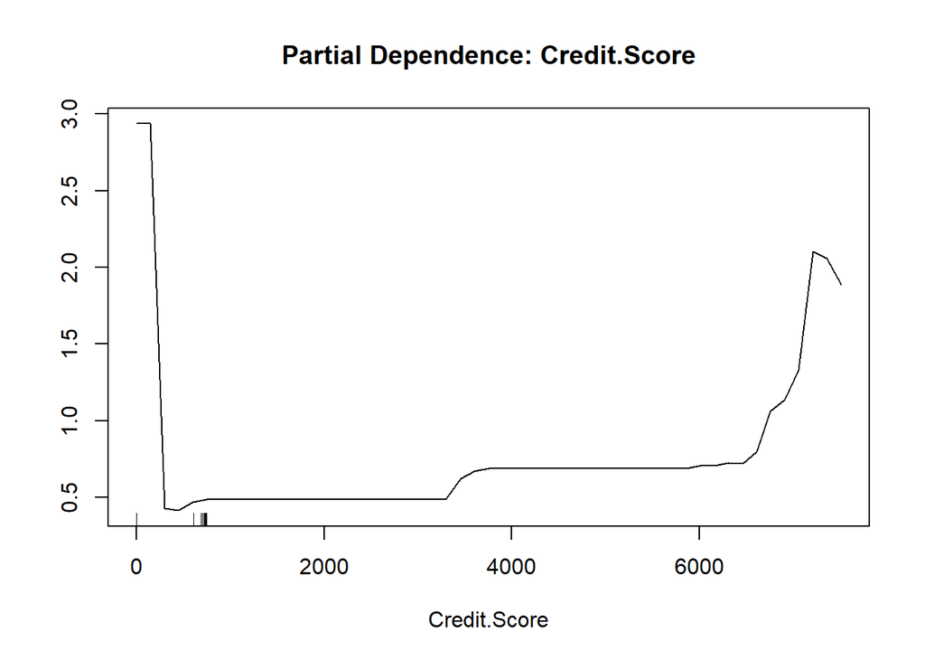

```r
partialPlot(rf_model, train_data, Credit.Score, main = "Partial Dependence: Credit.Score")
```

Based on many predictors, the algorithm fits a Logistic Regression model (log_reg_model) to forecast LoanApproval. It models the likelihood of loan approval using the glm function with a binomial family. The test data is used to make the predictions, and anticipated probabilities greater than 0.5 are categorized as 1 (approved). The confusion matrix, or log_reg_conf_matrix, is used to evaluate the model’s performance.

```r
# Logistic Regression Model
log_reg_model <- glm(LoanApproval ~ Annual.Income + DTI +
Credit.Score + Years.in.current.job + Credit.Utilization +
Home.Ownership + Purpose,data = train_data, family = binomial)
log_reg_predictions <- predict(log_reg_model, test_data, type = "response")
log_reg_predictions <- ifelse(log_reg_predictions > 0.5, 1, 0)
log_reg_predictions <- factor(log_reg_predictions, levels = levels(test_data$LoanApproval))
log_reg_conf_matrix <- confusionMatrix(log_reg_predictions,
test_data$LoanApproval)

print(log_reg_conf_matrix)
```

```
## Confusion Matrix and Statistics
##
##           Reference
## Prediction     0     1
##          0 21521  6851
##          1   684  1098
##
##                Accuracy : 0.7501
##                  95% CI : (0.7452, 0.755)
##     No Information Rate : 0.7364
##     P-Value [Acc > NIR] : 2.747e-08
##
##                   Kappa : 0.1429
##
##  Mcnemar's Test P-Value : < 2.2e-16
##
##             Sensitivity : 0.9692
##             Specificity : 0.1381
##          Pos Pred Value : 0.7585
##          Neg Pred Value : 0.6162
##              Prevalence : 0.7364
##          Detection Rate : 0.7137
##    Detection Prevalence : 0.9409
##       Balanced Accuracy : 0.5537
##
##        'Positive' Class : 0
##
```

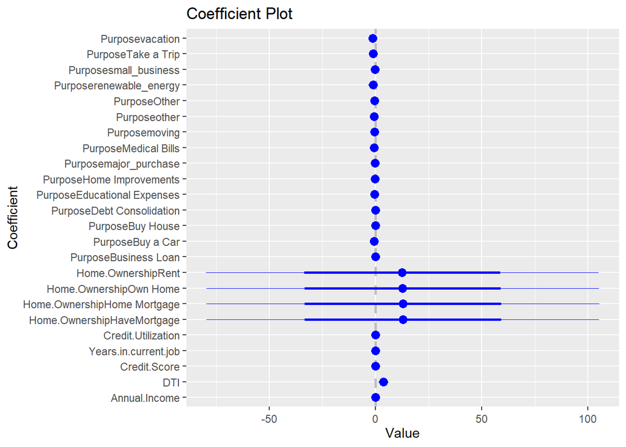

```r
coefplot(log_reg_model, intercept = FALSE, main = "Feature Importance")
```

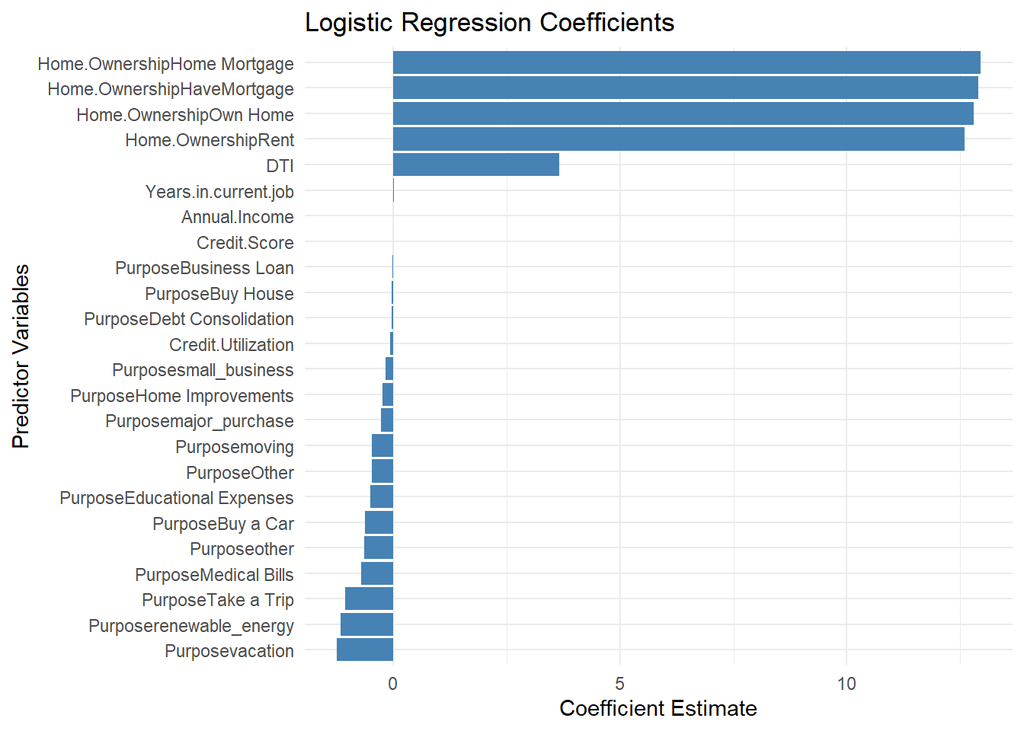

```r
# Extract Coefficients
coefficients <- summary(log_reg_model)$coefficients

# Data Frame
coeff_df <- data.frame(
  Predictor = rownames(coefficients),
  Estimate = coefficients[, "Estimate"]
)

# Remove the intercept
coeff_df <- coeff_df[coeff_df$Predictor != "(Intercept)", ]


# Bar Chart
ggplot(coeff_df, aes(x = reorder(Predictor, Estimate), y = Estimate)) +
  geom_bar(stat = "identity", fill = "steelblue") +
  coord_flip() +
  theme_minimal() +
  labs(title = "Logistic Regression Coefficients",
       x = "Predictor Variables",
       y = "Coefficient Estimate")
```

The goal variable, LoanApproval, is used to train the Gradient Boosting model (gb_model), which makes predictions about it using a number of features. The predict() method is used to make the model’s predictions, and the results are classified using a threshold of 0.5. A confusion matrix is generated to evaluate the model’s performance, comparing predicted values with actual values Lastly, the summary() function is used to illustrate the feature importance, illustrating how each predictor affects the model’s predictions.

```r
# Gradient Boosting Model
train_data$LoanApproval <- as.numeric(as.character(train_data$LoanApproval))
test_data$LoanApproval <- as.numeric(as.character(test_data$LoanApproval))

gb_model <- gbm(LoanApproval ~ Annual.Income + DTI +
Credit.Score + Years.in.current.job + Credit.Utilization +
  Home.Ownership + Purpose,
                data = train_data,
                distribution = "bernoulli",
                n.trees = 100,
                interaction.depth = 3,
                shrinkage = 0.01)

gb_predictions <- predict(gb_model, test_data,
n.trees = 100, type = "response")
gb_predictions <- ifelse(gb_predictions > 0.5, 1, 0)
gb_predictions <- factor(gb_predictions, levels = c(0, 1))
test_data$LoanApproval <- factor(test_data$LoanApproval,
levels = c(0, 1))
gb_conf_matrix <- confusionMatrix(gb_predictions,
test_data$LoanApproval)

print(gb_conf_matrix)
```

```
## Confusion Matrix and Statistics
##
##           Reference
## Prediction     0     1
##          0 22205  7949
##          1     0     0
##
##                Accuracy : 0.7364
##                  95% CI : (0.7314, 0.7414)
##     No Information Rate : 0.7364
##     P-Value [Acc > NIR] : 0.503
##
##                   Kappa : 0
##
##  Mcnemar's Test P-Value : <2e-16
##
##             Sensitivity : 1.0000
##             Specificity : 0.0000
##          Pos Pred Value : 0.7364
##          Neg Pred Value :    NaN
##              Prevalence : 0.7364
##          Detection Rate : 0.7364
##    Detection Prevalence : 1.0000
##       Balanced Accuracy : 0.5000
##
##        'Positive' Class : 0
##
```

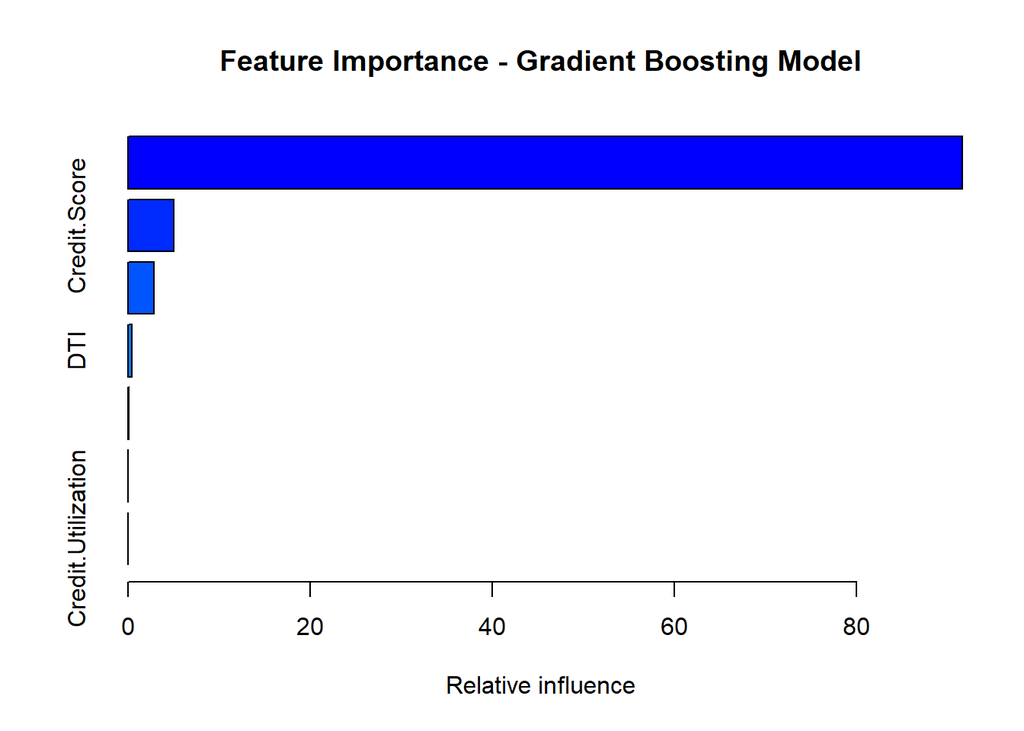

|  | var | rel.inf |
| --- | --- | --- |
| Annual.Income | Annual.Income | 91.6016831 |
| Credit.Score | Credit.Score | 5.0440593 |
| Purpose | Purpose | 2.8844641 |
| DTI | DTI | 0.4046254 |
| Home.Ownership | Home.Ownership | 0.0651681 |
| Years.in.current.job | Years.in.current.job | 0.0000000 |
| Credit.Utilization | Credit.Utilization | 0.0000000 |

```r
# Visualize
summary(gb_model, main = "Feature Importance - Gradient Boosting Model")
```

The Neural Network model (`ann_model`) is trained using the `nnet` package, with 5 hidden neurons and regularization (decay) to avoid overfitting. After training, predictions are made on the test data, and the results are converted to a factor for comparison with actual values. A confusion matrix (`ann_conf_matrix`) is generated to evaluate the model’s performance. The `plotnet()` function is used to visualize the neural network structure, showcasing the relationships between input features and output predictions.

```r
train_data$LoanApproval <- factor(train_data$LoanApproval, levels = c(0, 1))
test_data$LoanApproval <- factor(test_data$LoanApproval, levels = c(0, 1))

# Neural Network Model
set.seed(123)  # For reproducibility
ann_model <- nnet(
  LoanApproval ~ Annual.Income + DTI + Credit.Score + Years.in.current.job
  + Credit.Utilization + Home.Ownership + Purpose,
  data = train_data,
  size = 5,
  decay = 0.01,
  maxit = 200,
  linout = FALSE
)
ann_predictions <- predict(ann_model, newdata = test_data, type = "class")

ann_predictions <- factor(ann_predictions,
levels = levels(test_data$LoanApproval))

# Confusion Matrix
ann_conf_matrix <- confusionMatrix(ann_predictions,
test_data$LoanApproval)
print(ann_conf_matrix)
```

```
## Confusion Matrix and Statistics
##
##           Reference
## Prediction     0     1
##          0 20492  5756
##          1  1713  2193
##
##                Accuracy : 0.7523
##                  95% CI : (0.7474, 0.7572)
##     No Information Rate : 0.7364
##     P-Value [Acc > NIR] : 1.413e-10
##
##                   Kappa : 0.2375
##
##  Mcnemar's Test P-Value : < 2.2e-16
##
##             Sensitivity : 0.9229
##             Specificity : 0.2759
##          Pos Pred Value : 0.7807
##          Neg Pred Value : 0.5614
##              Prevalence : 0.7364
##          Detection Rate : 0.6796
##    Detection Prevalence : 0.8705
##       Balanced Accuracy : 0.5994
##
##        'Positive' Class : 0
##
```

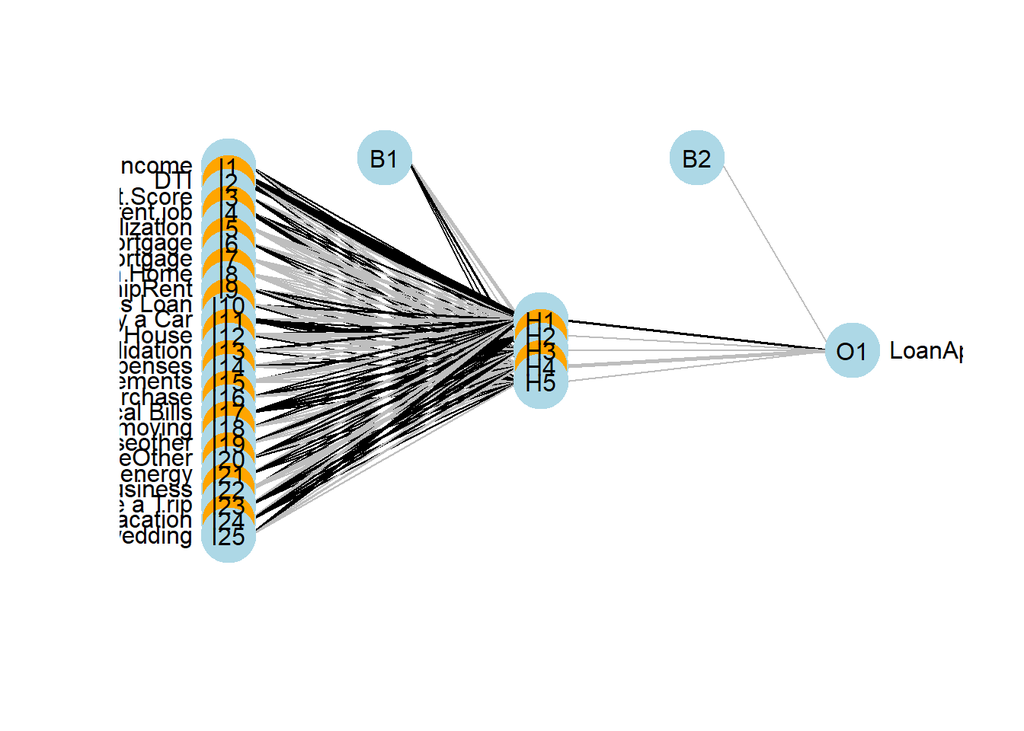

```r
# Visualize
plotnet(ann_model, circle_col = c("lightblue", "orange"))
```

Based on confusion matrices, the evaluate_model function computes evaluation metrics (Accuracy, Precision, Recall, and F1 Score) for various classification models. Confusion matrices of Random Forest, Logistic Regression, Gradient Boosting, Decision Tree, and Artificial Neural Network models are all subjected to the function. The final table including these measurements is printed to assess and compare the model performance after the metrics are saved in a data frame for comparison.

```r
# Function evaluation metrics
evaluate_model <- function(conf_matrix) {
  accuracy <- conf_matrix$overall['Accuracy']
  precision <- conf_matrix$byClass['Pos Pred Value']
  recall <- conf_matrix$byClass['Sensitivity']
  f1_score <- 2 * (precision * recall) / (precision + recall)

  return(list(
    Accuracy = accuracy,
    Precision = precision,
    Recall = recall,
    F1_Score = f1_score
  ))
}


rf_conf_matrix <- confusionMatrix(factor(rf_predictions), factor(test_data$LoanApproval))
log_reg_conf_matrix <- confusionMatrix(log_reg_predictions,
test_data$LoanApproval)
gb_conf_matrix <- confusionMatrix(gb_predictions, test_data$LoanApproval)
dt_conf_matrix <- confusionMatrix(factor(dt_predictions), factor(test_data$LoanApproval))
ann_conf_matrix <- confusionMatrix(ann_predictions, test_data$LoanApproval)

# Calculate
rf_metrics <- evaluate_model(rf_conf_matrix)
log_reg_metrics <- evaluate_model(log_reg_conf_matrix)
gb_metrics <- evaluate_model(gb_conf_matrix)
dt_metrics <- evaluate_model(dt_conf_matrix) # Added Decision Tree
ann_metrics <- evaluate_model(ann_conf_matrix)

# Combine
model_comparison <- data.frame(
  Model = c("Random Forest", "Logistic Regression",
"Gradient Boosting", "Decision Tree", "Artificial Neural Network"),
  Accuracy = c(rf_metrics$Accuracy, log_reg_metrics$Accuracy,
  gb_metrics$Accuracy, dt_metrics$Accuracy, ann_metrics$Accuracy),
  Precision = c(rf_metrics$Precision, log_reg_metrics$Precision, gb_metrics$Precision, dt_metrics$Precision, ann_metrics$Precision),
  Recall = c(rf_metrics$Recall, log_reg_metrics$Recall, gb_metrics$Recall, dt_metrics$Recall, ann_metrics$Recall),
  F1_Score = c(rf_metrics$F1_Score, log_reg_metrics$F1_Score,
gb_metrics$F1_Score, dt_metrics$F1_Score, ann_metrics$F1_Score))


print(model_comparison)
```

```
##                       Model  Accuracy Precision    Recall  F1_Score
## 1             Random Forest 0.7683226 0.7930224 0.9274488 0.8549840
## 2       Logistic Regression 0.7501161 0.7585295 0.9691961 0.8510192
## 3         Gradient Boosting 0.7363865 0.7363865 1.0000000 0.8481827
## 4             Decision Tree 0.7490217 0.7528416 0.9813556 0.8520430
## 5 Artificial Neural Network 0.7523048 0.7807071 0.9228552 0.8458506
```

Using AUC (Area Under the Curve) from ROC (Receiver Operating Characteristic) analysis, the given code assesses many models (Random Forest, Logistic Regression, Gradient Boosting, Decision Tree, and Artificial Neural Network). The projected probability for each model’s AUC values are computed and shown. The ROC curves for each model are plotted in various colors, with the baseline indicated by a diagonal line. The model names and associated AUC values are displayed in a legend that is appended to the plot. This makes it easier to compare the models’ performances visually.

```r
suppressMessages({
  suppressWarnings({
    rf_probabilities <- predict(rf_model, test_data, type = "prob")[, 2]
    rf_roc <- roc(test_data$LoanApproval, rf_probabilities)
    rf_auc <- auc(rf_roc)

    log_reg_probabilities <- predict(log_reg_model, test_data, type = "response")
    log_reg_roc <- roc(test_data$LoanApproval, log_reg_probabilities)
    log_reg_auc <- auc(log_reg_roc)

    gb_probabilities <- predict(gb_model, test_data, n.trees = 100, type = "response")
    gb_roc <- roc(test_data$LoanApproval, gb_probabilities)
    gb_auc <- auc(gb_roc)

    dt_probabilities <- predict(dt_model, test_data, type = "prob")[, 2]
    dt_roc <- roc(test_data$LoanApproval, dt_probabilities)
    dt_auc <- auc(dt_roc)

    ann_probabilities <- predict(ann_model, test_data, type = "raw")
    ann_roc <- roc(test_data$LoanApproval, ann_probabilities)
    ann_auc <- auc(ann_roc)

    # Print the AUC for each model
    cat("Random Forest AUC: ", rf_auc, "\n")
    cat("Logistic Regression AUC: ", log_reg_auc, "\n")
    cat("Gradient Boosting AUC: ", gb_auc, "\n")
    cat("Decision Tree AUC: ", dt_auc, "\n")
    cat("Artificial Neural Network AUC: ", ann_auc, "\n")
  })
})
```

```
## Random Forest AUC:  0.71536
## Logistic Regression AUC:  0.7000311
## Gradient Boosting AUC:  0.7075454
## Decision Tree AUC:  0.6753743
## Artificial Neural Network AUC:  0.7121075
```

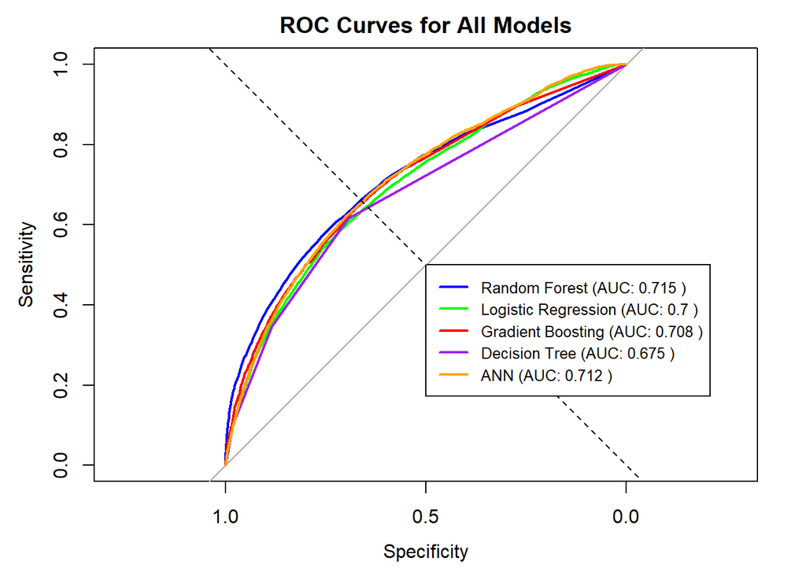

```r
plot(rf_roc, col = "blue", main = "ROC Curves for All Models", lwd = 2)
lines(log_reg_roc, col = "green", lwd = 2)
lines(gb_roc, col = "red", lwd = 2)
lines(dt_roc, col = "purple", lwd = 2)
lines(ann_roc, col = "orange", lwd = 2)


abline(a = 0, b = 1, col = "black", lty = 2)

legend(x = 0.5, y = 0.5,
       legend = c(paste("Random Forest (AUC:", round(rf_auc, 3), ")"),
                  paste("Logistic Regression (AUC:", round(log_reg_auc, 3), ")"),
                  paste("Gradient Boosting (AUC:", round(gb_auc, 3), ")"),
                  paste("Decision Tree (AUC:", round(dt_auc, 3), ")"),
                  paste("ANN (AUC:", round(ann_auc, 3), ")")),
       col = c("blue", "green", "red", "purple", "orange"),
       lwd = 2,
       cex = 0.8)
```